# Hands-on workshop: integration with PK

# 1 Preperation

## 1.1 Set Working Directory (WD)

R is always pointed at a directory on your computer. By default,

- R loads files (Plain text files / Data files etc.) from this directory.
- R outputs files (Plain text files / Data files etc.) to this directory.
- Set **W**orking **D**irectory (WD)
  - **On Windows**
    - in R interface choose : `Menu - File - Change dir...`
    - Choose a local directory (folder)
      - for example I use `C:/Users/Admin/Documents/Konstanz_summer_school/Day2` (actrually Day 3) as my working directory

[figure not shown]

[figure not shown]

  - **On MacOs**
    - in R insterface choose : `menu - Misc - Change Working Directory...`
      - for example I use `~/Documents/Konstanz_summer_school/Day2` as my working directory

[figure not shown]

[figure not shown]

  - **Verify your WD**
    - type `getwd()` in R console prompt: after `>`, then press `enter` key
    - R should print your current **WD**

## 1.2 Download dataset and load it to R

Copy - Paste in R console prompt: after `>`, then press `enter` key

```r
tmpData = readLines("https://antoinechn.github.io/Konstanz-SummerSchool/data/KBrO3_kinetics.txt")
writeLines(tmpData, "KBrO3_kinetics.txt")
rm(tmpData)
```

- once this is done, type `list.files()` in R console prompt: after `>`, then press `enter` key

```r
list.files()
```

- R should print all files in your working directory. Check if `KBrO3_kinetics.txt` is listed
- if still not
  - check your internet connection !!!
  - or contact us.

# 2 KBrO<sub>3</sub> in RPTEC cells

## 2.1 Load data

We will fist model the *in vitro* kinetics of KBrO<sub>3</sub> in RPTEC cells

```r
# read the data from a file
kinetic.data = read.table("KBrO3_kinetics.txt")
exists("kinetic.data")
```

```
#> [1] TRUE
```

**Try this**

```r
kinetic.data = read.table("https://trello-attachments.s3.amazonaws.com/59552633a56853b5f6d1f1f9/5a92760183331b90626ce166/f99b2b57b957d442cec69446144ff461/KBrO3_kinetics.txt")
exists("kinetic.data")
```

**Try this**

```r
kinetic.data = read.table("https://antoinechn.github.io/Konstanz-SummerSchool/data/KBrO3_kinetics.txt")
exists("kinetic.data")
```

## 2.2 Print `kinetic.data`

```r
# how big?
dim(kinetic.data)
```

```
#> [1] 8 3
```

```r
# small: look at them all
kinetic.data
```

```
#>   Time_min KbrO3_0.375_mM KbrO3_6_mM
#> 1        0     0.39045024  5.5169616
#> 2       10     0.35925946  6.0509875
#> 3       30     0.35798229  5.3599852
#> 4       60     0.28181038  5.9220955
#> 5      120     0.27791908  5.3840379
#> 6      240     0.22706964  3.6457820
#> 7      400     0.16348662  2.5793488
#> 8     1440     0.01875724  0.2952517
```

## 2.3 Plot `kinetic.data`

- Plot the data to get a sense of it

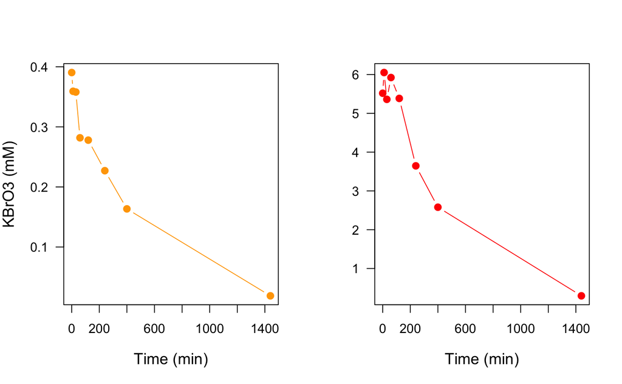

```r
# plot them on two panels
par(mfrow=c(1,2)) # One row, Two columns
plot(kinetic.data[,1], kinetic.data[,2], las=1, type="b",
     xlab="Time (min)", ylab="KBrO3 (mM)",
     log="", pch=16, cex=1.3, cex.lab=1.2, col="orange")
plot(kinetic.data[,1], kinetic.data[,3], las=1, type="b",
     xlab="Time (min)", ylab="",
     log="", pch=16, cex=1.3, cex.lab=1.2, col="red")
```

## 2.4 Kinetic Modelling

Now we need a model for those data. They look like decreasing exponentially (quite usual). It is customary to look at them on a log y-scale.

### 2.4.1 Plot the data on a log y-scale

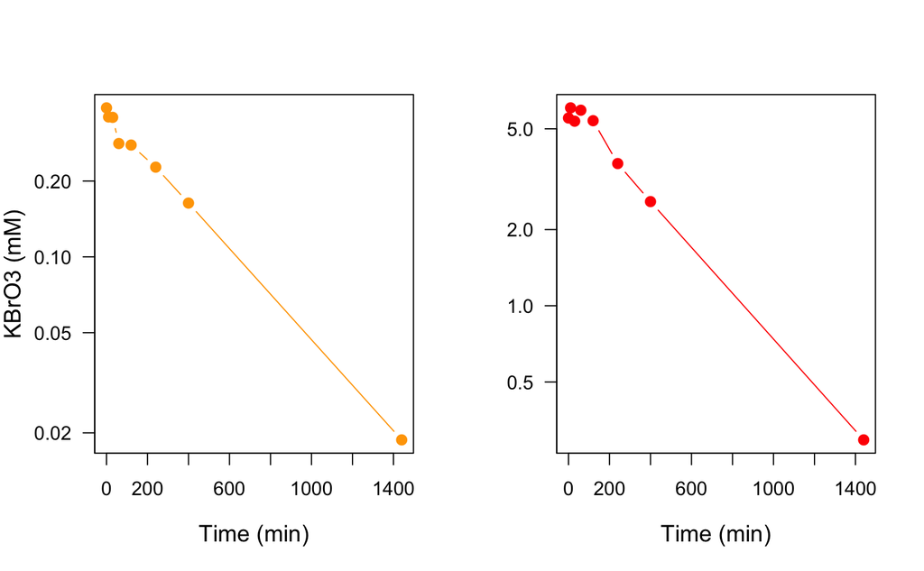

```r
par(mfrow=c(1,2))
plot(kinetic.data[,1], kinetic.data[,2], las=1, type="b",
     xlab="Time (min)", ylab="KBrO3 (mM)",
     log="y", pch=16, cex=1.3, cex.lab=1.2, col="orange")
plot(kinetic.data[,1], kinetic.data[,3], las=1, type="b",
     xlab="Time (min)", ylab="",
     log="y", pch=16, cex=1.3, cex.lab=1.2, col="red")
```

### 2.4.2 Model

It seems that there is only one line (not two or more lines joined with different slopes). In this case a mono-exponential decrease model will probably do. That model would be:

$$KBrO_3 = C_0 \times e^{-k \cdot \text{time}}$$

#### Question

- What values should we give to parameters $C_0$ and $k$?
  - for $C_0$ ?
  - for $k$, try different values till you match the low dose data, let’s begin with $k = 0$ :

$C_0$ is obvious $0.375$

```r
C0 = 0.375
```

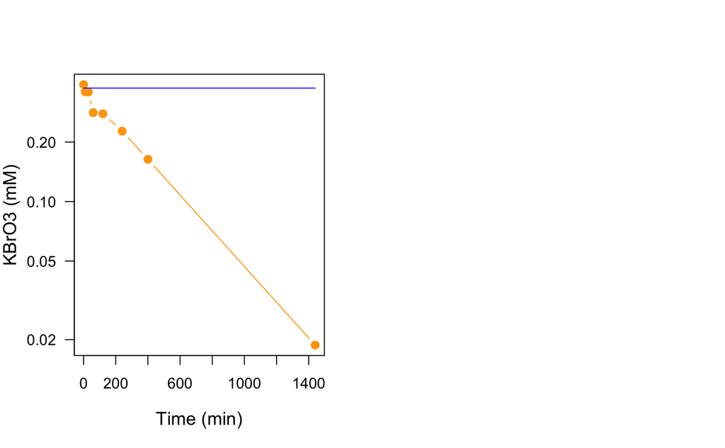

```r
k = 0 # Try different values till you match the low dose data

KBrO3 = C0 * exp(-k * kinetic.data[,1])

par(mfrow=c(1,2))
plot(kinetic.data[,1], kinetic.data[,2], las=1, type="b",
     xlab="Time (min)", ylab="KBrO3 (mM)",
     log="y", pch=16, cex=1.3, cex.lab=1.2, col="orange")
lines(kinetic.data[,1], KBrO3, col="blue")
```

#### Exercise

- repeat the above lines, changing k value, till you find a decent fit
- report the value found:
  $$k = ?$$

#### Solution

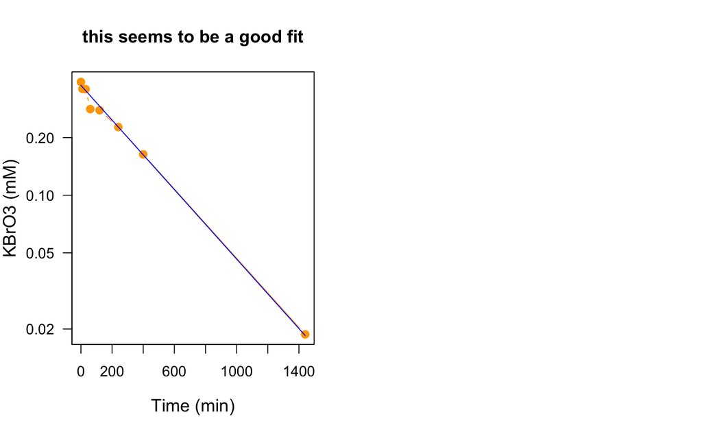

- `C0 = 0.375`
- `k = 0.00209`

```r
C0 = 0.375
k = 0.00209

KBrO3 = C0 * exp(-k * kinetic.data[,1])
par(mfrow=c(1,2))
plot(kinetic.data[,1], kinetic.data[,2], las=1, type="b",
     xlab="Time (min)", ylab="KBrO3 (mM)",
     log="y", pch=16, cex=1.3, cex.lab=1.2, col="orange",
     main = "this seems to be a good fit")
lines(kinetic.data[,1], KBrO3, col="blue")
```

#### Exercise

- Does it work at high dose? ($k$ might depend on the dose…)
- how would you check it?

#### Solution

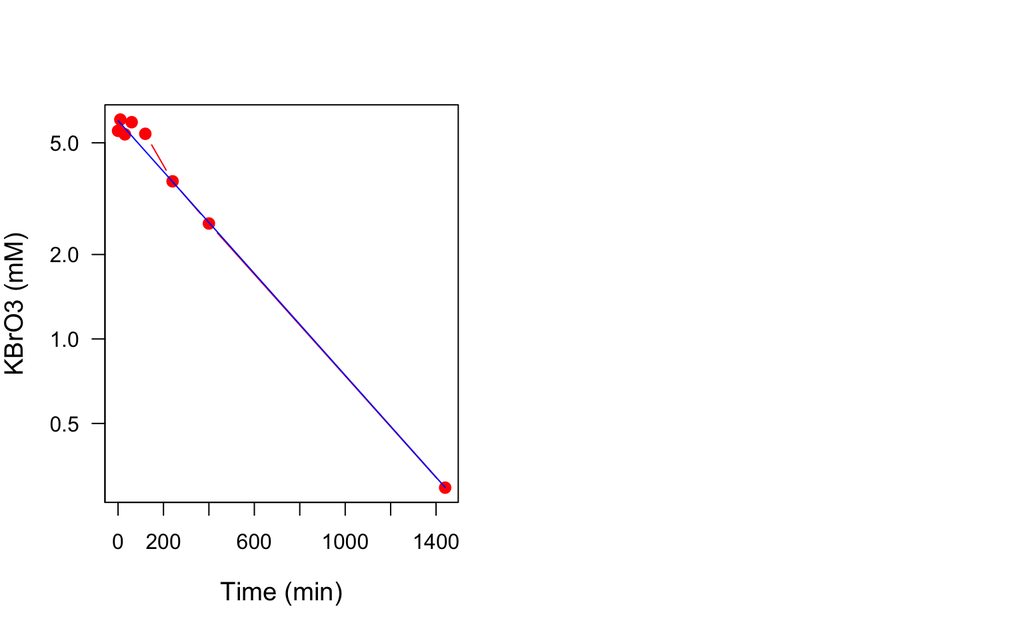

```r
C0 = 6
k = 0.00209

KBrO3 = C0 * exp(-k * kinetic.data[,1])
par(mfrow=c(1,2))
plot(kinetic.data[,1], kinetic.data[,3], las=1, type="b",
     xlab="Time (min)", ylab="KBrO3 (mM)",
     log="y", pch=16, cex=1.3, cex.lab=1.2, col="red")
lines(kinetic.data[,1], KBrO3, col="blue")
```

# 3 KBrO<sub>3</sub> - GHS - Kinetics

OK, so now we should have the KBrO<sub>3</sub> kinetics about OK. let’s reanalyze the KBrO<sub>3</sub> - GSH data, taking the kinetics into account.

## 3.1 Load `data_GSH`

```r
# re-read the GSH data
data_GSH = read.table("data_GSH.txt", sep="\t", header=TRUE)
data_GSH
# replot the data
plot(data_GSH$KBrO3_mM, data_GSH$pct_control)
```

Remember that we have fitted a Hill dose-response model to that data

```r
Hill = function (x, EC50, n, from, diff) {
  return(from + diff * (x^n / (x^n + EC50^n)))
}
```

## Discussion

`x` was the nominal (initial) concentration of `KBrO3` in the medium, but now we know that `KBrO3` disappears progressively (probably by reduction to bromide).

- So, what should be `x`?
  - should we take the concentration of KBrO3 at 1 hour ?
  - or the average concentration over the 1st hour?

**Recall** The `GSH` measurements were made after 1 hour.

```r
# If we take the concentration at 1h we should use
KBrO3 = C0 * exp(-k * 1 * 60) # 1 hour is 60 minutes...
```

```r
# If we take the average we should use
KBrO3 = (-C0*exp(-k * 60)/k + C0*exp(0)/k) / (60 - 0)
```

### Questions

**Does it make any difference? why?**

### Plot the `GSH` data as a funtion of `KBr03` concentration at 60 min

- Define a sequence of nominal concentrations

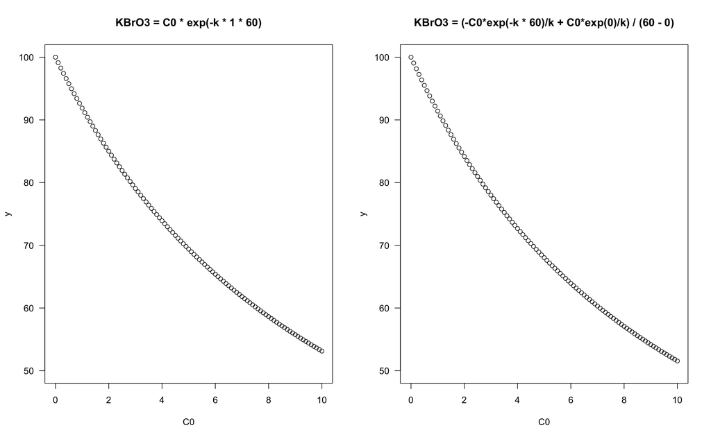

```r
Hill = function (x, EC50, n, from, diff) {
  return(from + diff * (x^n / (x^n + EC50^n)))
}
# define an extended Hill dose-response model as a function

C0 = seq(0, 10, 0.1)
# the actual bromate concentration seen by the cells was:
par(mfrow= c(1,2))
KBrO3 = C0 * exp(-k * 1 * 60) # Model 1
y = Hill(x=KBrO3, EC50=10, n=1, from=100, diff=-100)
plot(C0, y, type="b", main = "KBrO3 = C0 * exp(-k * 1 * 60)", ylim = c(50, 100), las = 1)

KBrO3 = (-C0*exp(-k * 60)/k + C0*exp(0)/k) / (60 - 0)
y = Hill(x=KBrO3, EC50=10, n=1, from=100, diff=-100) # Model 2
plot(C0, y, type="b", main = "KBrO3 = (-C0*exp(-k * 60)/k + C0*exp(0)/k) / (60 - 0)", ylim = c(50, 100), las = 1)
```

### Exercise

Now replot the data and overlay with the model

**Remark** make sure to define the axes limits before doing overlays…

[figure not shown]

```r
xlims = c(0, 6) # a vector of min and max
ylims = c(0, 120)
KBrO3.experimental.1h = data_GSH$KBrO3_mM * exp(-k * 1 * 60)
plot(KBrO3.experimental.1h, data_GSH$pct_control, xlim=xlims, ylim=ylims, col="red",
     xlab = "KBrO3 concentration at 1h (mM)", ylab = "GSH (% of control)",
     cex.lab = 1.4, las = 1)
par(new=T) # will overlay the next plot
y = Hill(x = KBrO3, EC50 = 1, n = 1, from = 100, diff = -100)
plot(C0, y, type="l", xlim=xlims, ylim=ylims, xlab="", ylab="",
     xaxt = "n", yaxt = "n", col = "red", lwd = 2.5) # turn off labels
```

- now play with EC50 and N to fit the data better

**we have coupled PK and PD (dose-response)**

[output not shown]